# Environmental DNA (eDNA) metabarcoding differentiates between micro-habitats within the rocky intertidal

Meghan M. Shea

2023-07-20

```r
#Install & Load Requires Packages
#Check if all required packages have been installed and loaded, and if not, install and load them.

options(repos = list(CRAN="http://cran.rstudio.com/"))

packages <- c("tidyverse",
              "sf",
              "patchwork",
              "stringr",
              "BiocManager",
              "remotes",
              "eulerr",
              "indicspecies",
              "cluster",
              "vegan",
              "chisq.posthoc.test",
              "taxize",
              "Polychrome",
              "pals",
              "spocc",
              "mregions",
              "rgbif",
              "mapview",
              "ggbeeswarm",
              "ggh4x",
              "chunkhooks")

install.packages(setdiff(packages, rownames(installed.packages())))

if(!require("phyloseq", quietly=TRUE))
  BiocManager::install("phyloseq")

if(!require("ggtree", quietly=TRUE))
  BiocManager::install("ggtree")

if(!require("ggtreeExtra", quietly=TRUE))
  BiocManager::install("ggtreeExtra")

if(!require("ampvis2", quietly=TRUE))
  remotes::install_github("kasperskytte/ampvis2")


#most recent CRAN update for tidytree broke my phylogenetic tree code; see if I can troubleshoot at some point
if(!require("tidytree", quietly=TRUE))
  install_version("tidytree", version = "0.4.2")

packages = append(packages, c("phyloseq", "ampvis2", "ggtree", "ggtreeExtra", "tidytree"))
invisible(lapply(packages, library, character.only = TRUE))

hook_figure_unit()
```

### Materials and Methods

#### 2.1 Detailed Protocols

To improve reproducibility (e.g. Dickie et al., 2018; Shea et al., 2023) and aid in the initiation of new eDNA biomonitoring projects, we have published detailed, step-by-step protocols for many of the methods described, including specific materials used, photographs, and additional methodological notes not possible to include here. See Shea (2023) for sample collection and filtering, Shea (2023) for DNA extractions, Shea (2023) for PCR amplification, and Shea (2023) for shipping samples.

#### 2.2 Sampling Site

To better understand the spatial and temporal scales of eDNA detections in a complex coastal environment, we sought a rocky intertidal field location that had consistent, large, accessible tide pools that were fully isolated from one another at some low tides but interconnected during other parts of their exposure period. We selected the intertidal at Pillar Point, a headlands promontory to the west of Pillar Point Harbor in San Mateo County, California, USA. Pillar Point is a popular recreational intertidal site that is directly adjacent to the Pillar Point State Marine Conservation Area (no specific use scientific collection permit required).

Within Pillar Point, we sampled at three discrete locations: two individual tide pools with a range of physical connectivity (Tide Pool 1, S1: 37.495342°, -122.498731°; Tide Pool 2, S2: 37.495000°, -122.498947°) and an equidistant location (Nearshore, N: 37.4952833°, -122.4992056°) where there was well-mixed offshore water for the duration of the tidal cycle (Figure 2; not produced in R). Each site was approximately 40 meters from all other sites. Tide Pool 1 and Tide Pool 2 are fully isolated at tidal heights of around 0 m (mean low low water, MLLW) or lower, and substantially connected at around 0.25 m or higher. On the day we sampled, this meant water actively flowed between the locations at the start (11:30 am PST) and end (17:00 pm PST) of the sampling period, but that the sites were disconnected at low tide in the middle of the sampling period.

#### 2.3 Sample Collection & Filtration

We collected 1 L surface samples from each location every 30 minutes for the duration of time the intertidal was exposed on 28 January 2022, using single-use enteral feeding pouches (Covidien, Dublin, Ireland). Sampling commenced at 11:30 am PST; the exact times of sample collection, in relation to the tide, are shown in Figure 3. Following the approach used by Gold et al. (2021b), we attached a sterile 0.22 $\mu$m pore size Sterivex cartridge (MilliporeSigma, Burlington, MA, USA) to the tubing of each feeding pouch, allowing samples to be immediately gravity filtered in the field. While gravity filtering (1-2 hours per sample), samples were shaded with an awning to prevent any degradation by sunlight (Andruszkiewicz et al., 2017).

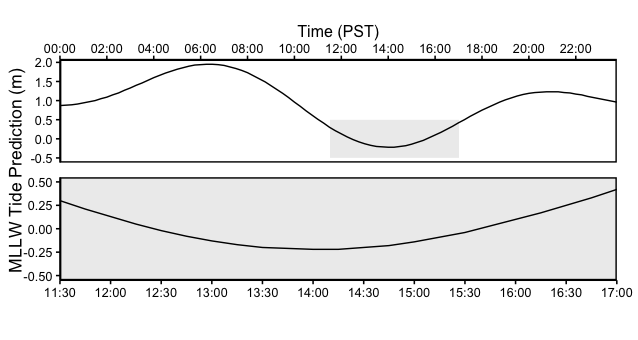

```r
#Read Pillar Point NOAA/NOS/CO-OPs Tide Chart data file
Tides = read.table("Data/28-Jan-2022-TideChart.txt", header = TRUE, sep = "", dec = ".", skip=13)

#Convert date format in table using lubridate
Tides$datetime <- lubridate::ymd_hm(paste(Tides$Date, Tides$Time), tz = "US/Pacific")

#Set bounds of sampling period to highlight
xmin = Tides$datetime[47]
xmax = Tides$datetime[69]
ymin = -.5
ymax = .5

box_color = "#EDEDED"

#Create plot of full tidal cycle with sampling period highlighted
p1 <- ggplot(data=Tides, aes(x=datetime, y = Pred, group=1)) +
  annotate("rect", xmin = xmin, xmax = xmax, ymin = ymin, ymax = ymax, fill = box_color) +
  geom_line() +
  coord_cartesian(xlim = c(Tides$datetime[1], Tides$datetime[96])) +
  theme_classic(base_size = 12) +
  theme(
    panel.background = element_rect(fill = "transparent", colour = NA_character_),
    # necessary to avoid drawing panel outline
    plot.background = element_rect(fill = "transparent", colour = NA_character_),
    # necessary to avoid drawing plot outline
    axis.text.x = element_text(color="black"),
    axis.ticks = element_line(color = "black"),
    axis.text.y = element_text(color="black"),
    panel.border = element_rect(colour = "black", fill=NA, linewidth=1)
  ) +
  xlab("Time (PST)") +
  ylab("MLLW Tide Prediction (m)") +
  scale_x_datetime(date_breaks = "2 hour", date_labels = "%H:00", expand = c(0, 0), position = "top")

#Create plot of just sampling period
p2 <- ggplot(data=Tides, aes(x=datetime, y = Pred, group=1)) +
  geom_line() +
  coord_cartesian(xlim = c(xmin, xmax), ylim = c(ymin, ymax)) +
  theme_classic(base_size = 12) +
  theme(panel.background = element_rect(fill = box_color),
        plot.background = element_rect(fill = "transparent", colour = NA_character_),
        axis.text.x = element_text(color="black"),
        axis.ticks = element_line(color = "black"),
        axis.text.y = element_text(color="black"),
        panel.border = element_rect(colour = "black", fill=NA, linewidth=1)) +
  xlab("") +
  ylab("MLLW Tide Prediction (m)") +
  scale_x_datetime(date_breaks = "30 min", date_labels = "%H:%M", expand = c(0, 0))

#Stitch plots together using patchwork
p_patch <- p1 / p2 & ylab(NULL) & theme(plot.margin = margin(5.5, 5.5, 5.5, 0), plot.background = element_rect(fill = "transparent", colour = NA_character_))

# Use the tag label as a y-axis label
p_patch = wrap_elements(p_patch) +
  labs(tag = "MLLW Tide Prediction (m)") +
  theme(
    plot.tag = element_text(size = rel(1.2), angle = 90),
    plot.tag.position = "left",
    plot.background = element_rect(fill = "transparent", colour = NA_character_)
  )

p_patch
```

```r
ggsave(
  plot = p_patch,
  filename = "Figures/Figure3.png",
  device = "png",
  bg = "transparent",
  width = 169,
  height = 90,
  units = "mm",
  dpi = 600
)


##Second section of plot continued below once data has been loaded
```

At three time points (see Figure 3; additional items added outside of R) at the beginning and end of the sampling period as well as at low tide, we collected triplicate 1 L samples from each location as biological replicates. At the beginning and end of the sampling period, we also filtered 1 L MilliQ water via the procedure described above to serve as negative field controls. Additionally, using an Orion Model 1230 meter (Orion Research Inc., Beverly, MA, USA), we recorded temperature and salinity in each location directly after samples were collected.

Once finished filtering, Sterivex cartridges were dried by pushing air through them using a sterile 3 mL syringe, capped, placed in sterile Whirl-Pak bags (Whirl-Pak, Madison, WI, USA). Then, samples were stored in a cooler on ice until transported back to the laboratory at the end of the sampling period. Samples were transferred to a -20°C freezer for up to 18 days, at which time they were processed to extract nucleic acids from the captured materials.

#### 2.4 DNA Extraction & Library Preparation

Within 18 days of collection, we extracted DNA from the Sterivex cartridge using the DNeasy Blood and Tissue Kit (Qiagen, Germantown, MD, USA) and the modifications described in Spens et al. (2017). In short, we incubated the filter cartridge overnight with proteinase K and ATL. Then, we extracted the liquid from the cartridge with a syringe and mixed it with equal volumes of AL buffer and 0°C ethanol before proceeding with the manufacturer’s extraction protocol. One negative extraction control (DNA-grade water in place of a sample) was included in each of four batches of extractions. Extracted samples to be PCR amplified were stored at -20°C for up to 6 months.

We PCR amplified the extracted DNA in triplicate within 6 months of storage, using the mlCOIintF/ jgHCO2198 primer set targeting a 313 bp fragment of the mitochondrial COI region optimized by Leray et al. (2013) (Forward: GGWACWGGWTGAACWGTWTAYCCYCC; Reverse: TAIACYTCIGGRTGICCRAARAAYCA) with Nextera modifications. Following Curd et al. (2019), we used a 25 $\mu$l PCR reaction mixture consisting of 12.5 $\mu$l of Qiagen Multiplex Mix (Qiagen, Germantown, MD, USA), 2.5 $\mu$l each of the forward and reverse primers at 2 $\mu$M (Integrated DNA Technologies, Inc., Coralville, IA, USA), 6.5 $\mu$l of PCR-grade water, and 1 $\mu$l of undiluted DNA template. The PCR thermocycling touchdown profile began with an initial denaturation at 95° for 15 minutes to activate the DNA polymerase, followed by 13 cycles of denaturation (94° for 30 seconds), annealing (starting at 69.5° for 30 seconds, with the temperature decreased by 1.5° each cycle), and extension (72° for 1 minute). Then, an additional 35 cycles were run with the same denaturation and extension steps as above with an annealing temperature of 50°, followed by a final extension at 72° for 10 minutes. PCR reactions were prepared in a designated DNA-free hood until the template was added.

PCR amplification was conducted in two batches; in each batch, we included one no-template negative PCR control (DNA-grade water used as template). Additionally, we extracted DNA from tissue from five organisms across a range of phyla we expected to amplify with the mlCOIintF/ jgHCO2198 primers, but not expected to be present at Pillar Point in particular (Mytilus edulis, Mizuhopecten yessoensis, Xiphias gladius, Mercenaria mercenaria, Lutjanus campechanus) using the standard tissue extraction protocol detailed in the DNeasy Blood and Tissue Kit (Qiagen, Germantown, MD, USA). These tissues were obtained from a local grocery store and it was assumed that they were labeled correctly, although previous work has indicated mislabeling in seafood stores can occur (e.g. Willette et al., 2017). Extracts from the 5 tissue samples were combined in equimolar amounts to form a mock community used as a positive PCR control in each batch. Triplicate PCR amplicons from both samples and controls were not subsequently pooled, but were carried through the remaining library preparation and sequencing steps as technical replicates. We electrophoresed and visualized a subset of PCR products on a 1.5% agarose gel stained with GelRed® (Biotium, Fremont, CA, USA) to ensure successful amplification and correct product sizes as well as lack of contamination.

Post-PCR library preparation and sequencing was conducted at the Georgia Genomics and Bioinformatics Core (GGBC, UG Athens, GA, RRID:SCR_010994). In short, provided PCR amplicons were cleaned using AMPure XP magnetic beads (Beckman Coulter, Indianapolis, IN, USA), barcoded with Nextera adapters (Illumina, San Diego, CA, USA) during a second PCR (3 min at 95°C; 15 cycles of 30 sec at 95°C, 30 sec at 67°C, and 30 sec at 72°C; and 4 min at 72°C), cleaned again using AMPureXP magnetic beads, and pooled in equimolar ratio. The resulting library was sequenced on a MiSeq PE 2x250bp (500 cycles) using Reagent Kit V2 with 25% PhiX spike-in (Illumina, San Diego, CA, USA). Given our technical replication of samples and controls, our final library included 6 negative field controls (1 at beginning and end of field sampling, amplified in triplicate), 12 negative extraction controls (1 in each of 4 extraction sets, amplified in triplicate), 2 positive PCR controls (1 in each of 2 amplification batches), 2 no-template negative PCR controls (1 in each of 2 amplification batches), and 159 samples (53 field samples, amplified in triplicate).

#### 2.5 Bioinformatics

```r
#Function that removes NCBI Taxonomy IDs from the end of a taxa name, from an Anacapa Output, in list form
remove_NCBInums = function(list) {
  list = sub("_[^_]+$","", list)
  return(list)
}

#Function that converts an ampvis2 object to a phyloseq object
#Can be used either on an existing ampvis object (abund, tax, md = NULL) or separate abund, tax, and metadata data frames (ampvis = NULL)
amp_to_phyloseq = function(ampvis, abund, tax, md) {
  if(!is.null(ampvis)) {
    physeq = phyloseq(otu_table(as.matrix(ampvis$abund), taxa_are_rows = TRUE),
                    tax_table(as.matrix(ampvis$tax)),
                    sample_data(ampvis$metadata))
  } else if (is.null(md)) {
    physeq = phyloseq(otu_table(as.matrix(abund), taxa_are_rows = TRUE),
                    tax_table(as.matrix(tax)))
} else {
  physeq = phyloseq(otu_table(as.matrix(abund), taxa_are_rows = TRUE),
                    tax_table(as.matrix(tax)),
                    sample_data(md))
}
  return(physeq)
}
```

```r
#Read in Anacapa Output; change p_confidence to switch to a different percent confidence output

current_subfolder = "Data/Anacapa Pipeline Output/Tide Pool 5184 - 31 January 2023"
p_confidence = 60
filepath = paste0(current_subfolder,
                  "/CO1/CO1_taxonomy_tables/Summary_by_percent_confidence/",
                  p_confidence,
                  "/CO1_ASV_raw_taxonomy_",
                  p_confidence,
                  ".txt")

AnacapaOutput = read.table(filepath, header = TRUE, sep = "\t", dec = ".")


#Format ASV Table (extract just the needed information)

endcol = ncol(AnacapaOutput) - 1
asvmat = AnacapaOutput[,2:endcol]
rownames(asvmat) <- AnacapaOutput[,1]

#Format Taxonomy Table (extract just the needed information and rename columns)

endcol = ncol(AnacapaOutput)
taxmat = AnacapaOutput[,endcol]
taxmat = str_split_fixed(taxmat, ";",7)

colnames(taxmat) <- c("Kingdom", "Phylum", "Class", "Order", "Family", "Genus", "Species")

rownames(taxmat) <- rownames(asvmat)

#Read Metadata (saved in multiple different files)

current_subfolder = paste0(current_subfolder, "/Metadata-Added/PillarPoint_SampleInfo_")

filepath = paste0(current_subfolder, "EnviroData.txt")
EnviroData = read.table(filepath, header = TRUE, sep = "\t", dec = ".", strip.white = TRUE)

filepath = paste0(current_subfolder, "FieldSampling.txt")
FieldSampling = read.table(filepath, header = TRUE, sep = "\t", dec = ".", strip.white = TRUE)
FieldSampling = FieldSampling[,1:4]

filepath = paste0(current_subfolder, "Sequencing.txt")
Sequencing = read.table(filepath, header = TRUE, sep = "\t", dec = ".", strip.white = TRUE)

filepath = paste0(current_subfolder, "Location.txt")
Location = read.table(filepath, header = TRUE, sep = "\t", dec = ".", strip.white = TRUE)

#Format Metadata

sampledata = merge(FieldSampling, EnviroData, all=T)
sampledata = sampledata %>% drop_na(Dereplicated_Sample_Name)
#removing one sample that has EnviroData reading but the field sample was not processed

sampledata = merge(Sequencing,sampledata, all=T)

rownames(sampledata) <- sampledata[,"X"]

sampledata$Dereplicated_Sample_Name = as.factor(sampledata$Dereplicated_Sample_Name)
sampledata$Type = as.factor(sampledata$Type)
sampledata$PCR = as.factor(sampledata$PCR)
sampledata$Time = as.factor(sampledata$Time)
sampledata$Location = as.factor(sampledata$Location)
sampledata$Extraction = as.factor(sampledata$Extraction)
sampledata$SiteByTime = as.factor(paste(sampledata$Location, sampledata$Time))

#Make ampvis2 objects without any pre-processing
asvmat_amp = tibble::rownames_to_column(asvmat, "ASV")
sampledata_amp = tibble::rownames_to_column(sampledata, "Sample")
taxmat_amp = tibble::rownames_to_column(as.data.frame(taxmat), "ASV")
amp = amp_load(asvmat_amp, metadata = sampledata_amp, taxonomy = taxmat_amp)

amp_nocontrols = amp_filter_samples(amp, Type %in% c("sample"))
```

```
## 22 samples and 3315 OTUs have been filtered
## Before: 181 samples and 71947 OTUs
## After: 159 samples and 68632 OTUs
```

```r
amp_controls = amp_filter_samples(amp, Type %in% c("control"))
```

```
## 159 samples and 68607 OTUs have been filtered
## Before: 181 samples and 71947 OTUs
## After: 22 samples and 3340 OTUs
```

```r
#Make ampvis2 objects with singletons removed
amp_NS = amp_load(asvmat_amp, metadata = sampledata_amp, taxonomy = taxmat_amp, pruneSingletons = TRUE)
```

```
## 41532 singletons have been removed
```

```r
amp_nocontrols_NS = amp_filter_samples(amp_NS, Type %in% c("sample"))
```

```
## 22 samples and 381 OTUs have been filtered
## Before: 181 samples and 30415 OTUs
## After: 159 samples and 30034 OTUs
```

```r
amp_controls_NS = amp_filter_samples(amp_NS, Type %in% c("control"))
```

```
## 159 samples and 30009 OTUs have been filtered
## Before: 181 samples and 30415 OTUs
## After: 22 samples and 406 OTUs
```

```r
#Make ampvis2 objects with a full decontamination procedure

#Function that removes any ASV that appears in any control from all samples
full_decontamination <-function(amp) {

  physeq = amp_to_phyloseq(amp, NULL, NULL, NULL)

  physeq_controls <- physeq %>%
    subset_samples(Type == "control") %>%
    prune_taxa(taxa_sums(.) >0, .)

  badASV = taxa_names(physeq_controls)
  allASV = taxa_names(physeq)
  allASV <- allASV[!(allASV %in% badASV)]
  physeq_FD = prune_taxa(allASV, physeq)

  av2_otutable <- data.frame(otu_table(physeq_FD)@.Data)
  av2_taxtable <- data.frame(tax_table(physeq_FD)@.Data)
  av2_metadata <- data.frame(sample_data(physeq_FD))

  amp_return <- amp_load(av2_otutable, metadata = av2_metadata, taxonomy = av2_taxtable)
  amp_return= amp_filter_samples(amp_return, Type %in% c("sample"))

  return(amp_return)
}

amp_nocontrols_FD = full_decontamination(amp)
```

```
## 22 samples and 0 OTUs have been filtered
## Before: 181 samples and 68607 OTUs
## After: 159 samples and 68607 OTUs
```

```r
amp_nocontrols_NS_FD = full_decontamination(amp_NS)
```

```
## 22 samples and 0 OTUs have been filtered
## Before: 181 samples and 30009 OTUs
## After: 159 samples and 30009 OTUs
```

```r
#Make ampvis2 objects by rarefying to the minimum number of reads of any sample

#Function that wraps around an ampvis2 function to rarefy samples to the minimum number of reads of any sample
rarefaction <- function(amp) {
  set.seed(0)
  reads <- colSums(amp$abund)
  minreads <- min(reads)
  amp_R = amp_subset_samples(amp, rarefy = minreads)
  return(amp_R)
}

amp_nocontrols_R = rarefaction(amp_nocontrols)
```

```
## 0 samples have been filtered.
```

```r
amp_nocontrols_NS_R = rarefaction(amp_nocontrols_NS)
```

```
## 0 samples have been filtered.
```

```r
amp_nocontrols_FD_R = rarefaction(amp_nocontrols_FD)
```

```
## 0 samples have been filtered.
```

```r
amp_nocontrols_NS_FD_R = rarefaction(amp_nocontrols_NS_FD)
```

```
## 0 samples have been filtered.
```

```r
##Create data frame for GBIF
#Exporting version of data with decontamination and controls removed but no additional processing

GBIF_export = amp_nocontrols_FD

GBIF_export$metadata = merge(GBIF_export$metadata, Location, all=T)

TimeZone = "UTC−08:00"
Date = "28 January 2022"
GBIF_export$metadata = cbind(GBIF_export$metadata, TimeZone)
GBIF_export$metadata = cbind(GBIF_export$metadata, Date)

names(GBIF_export$metadata)[names(GBIF_export$metadata) == 'Sample'] <- 'Sequencing_Sample_Name'

col_order = c("Sequencing_Sample_Name", "Sample_Name", "Location", "Latitude", "Longitude", "CRS", "Date", "Time", "TimeZone", "T", "S")
GBIF_export$metadata = GBIF_export$metadata[,col_order]

#Add sequences to file

current_subfolder = "Data/Anacapa Pipeline Output/Tide Pool 5184 - 31 January 2023"
filepath = paste0(current_subfolder,
                  "/CO1/CO1_taxonomy_tables/CO1_ASV_taxonomy_detailed.txt")

AnacapaDetailed = read.table(filepath, header = TRUE, sep = "\t", dec = ".")
sequences = as.data.frame(AnacapaDetailed[,"sequence"])
rownames(sequences) = AnacapaDetailed$CO1_seq_number

GBIF_export$tax = merge(sequences, GBIF_export$tax, by = "row.names", all.x = FALSE, all.y = TRUE, sort = FALSE)
rownames(GBIF_export$tax) = GBIF_export$tax$Row.names
names(GBIF_export$tax)[names(GBIF_export$tax) == "AnacapaDetailed[, \"sequence\"]"] <- 'Sequence'

col_order = c("Sequence", "Kingdom", "Phylum", "Class", "Order", "Family", "Genus", "Species")
GBIF_export$tax = GBIF_export$tax[,col_order]

write.csv(GBIF_export$abund, "Data/GBIF/ASVTable.csv", row.names=TRUE)
write.csv(GBIF_export$tax, "Data/GBIF/TaxTable.csv", row.names=TRUE)
write.csv(GBIF_export$metadata, "Data/GBIF/SampleData.csv", row.names=FALSE)
```

#### Data Analysis

To understand whether eDNA signals could be distinguished by location, we first analyzed individual-level differences between locations; that is, whether ASVs or individual taxa (agglomerated species-level taxonomic assignments) were unique to, or associated with, particular locations. We calculated and visualized unique ASVs and taxa using the `eulerr` (version 7.0.0 `packageVersion("eulerr")`) (Larsson, 2022) packages. However, with metabarcoding data in particular, taxa or ASVs that are unique to a given location are not necessarily ecologically meaningful; they could include rare taxa present elsewhere but not amplified and exclude taxa that are well correlated with particular locations but sometimes detected at others. Thus, we also analyzed ASVs and taxa using an indicator species framework (Dufrêne and Legendre, 1997). In this framework, the null hypothesis is that the frequency of a taxon’s or ASV’s presence in samples from a particular location is not higher that the frequency of that taxon’s or ASV’s presence in samples from other locations. For each location, we identified all statistically-significant indicator taxa and ASVs with indicator value indices above 0.7—that is, indicators that are well-associated with a site group even if they are detected in samples from other sites—based on presence-absence data per sample using the `indicspecies` package (version 1.7.13 `packageVersion("indicspecies")`) (Cáceres and Legendre, 2009).

We followed our individual-level analyses with approaches to test whether community composition varied by location. We calculated a Jaccard dissimilarity matrix across all samples using `vegan` (version 2.6.4 `packageVersion("vegan")`) (Oksanen et al., 2022). Then, we tested for differences in community composition among locations using a permutational multivariate analysis of variance (PERMANOVA) with the model eDNA Presence ~ Location + Time + Biological Replicates using the `adonis` function in `vegan`. We confirmed that locational differences found via PERMANOVA were not a result of differences in dispersions by testing for homogeneity of dispersions using the betadisper function in `vegan`. We also visualized Jaccard dissimilarity using non-metric multidimensional scaling (NMDS) using the `metaMDS` function in `vegan`. We coupled these analyses with a partitioning among medoids algorithm (Kaufman and Rousseeuw, 1990) implemented with the `pam` function in the `cluster` package (version 2.1.4 `packageVersion("cluster")`) (Maechler et al., 2022). Rather than assuming location clusters a priori, we validated the optimal number of clusters for a given dataset by finding the number of clusters (k) that maximized the average silhouette width, a measure of how well-structured the clusters are. Finally, to better understand how the difference between locations varied over the time sampled, for each time point, we calculated the Jaccard dissimilarity between each unique combination of replicates within each site, and then the pairwise Jaccard dissimilarity between each unique combination of samples across the three pairs of sites: S1-N, S2-N, and S1-S2.

To further understand whether differences in eDNA detections corresponded with underlying ecological gradients, we compared the unique and indicator taxa identified at each site to their ecological zonation in a highly regarded field guide to the Pacific intertidal, Between Pacific Tides (Ricketts et al., 1985). To account for potential variations in taxonomic names between Between Pacific Tides and the MIDORI2 reference database, we used the World Register of Marine Species (WoRMS) to identify all synonymized names for each unique and indicator taxon identified, and we searched Between Pacific Tides for all synonyms. We compared the proportion of high and middle intertidal species identified across each location using a chi-squared test with p-values computed via Monte Carlo simulation.

### Results

#### 3.1 Sequencing Results & Taxonomic Diversity

```r
#Gather information about full Anacapa Toolkit results before any processing
total_ASVs = nrow(amp$abund)
total_reads = sum(amp$abund)

samples = length(amp$metadata$Type[amp$metadata$Type == "sample"])
controls = length(amp$metadata$Type[amp$metadata$Type == "control"])

#Check positive PCR controls
amp_MC = amp_filter_samples(amp, Location %in% c("MC"))
```

```
## 179 samples and 71797 OTUs have been filtered
## Before: 181 samples and 71947 OTUs
## After: 2 samples and 150 OTUs
```

```r
df = merge(amp_MC$abund, amp_MC$tax, by = 'row.names')
df = df[,c(2:3, 10)]
colnames(df) = c("MC1", "MC2", "Species")
agg_df <- df %>% group_by(Species) %>% summarise(MC1_Reads = sum(MC1), MC2_Reads = sum(MC2)) %>% arrange(desc(MC1_Reads))
agg_df[agg_df == ""] = "No Taxonomic Assignment"

agg_df
```

| Species | MC1_Reads | MC2_Reads |
| --- | --- | --- |
| Xiphias gladius_8245 | 22811 | 14132 |
| Mizuhopecten yessoensis_6573 | 5565 | 2863 |
| Sebastes pinniger_72094 | 4900 | 2610 |
| Mercenaria mercenaria_6596 | 2133 | 1093 |
| Mytilus edulis_6550 | 195 | 74 |
| Oncorhynchus mykiss_8022 | 33 | 16 |
| Salmo salar_8030 | 12 | 0 |
| No Taxonomic Assignment | 11 | 2 |
| Anoplopoma fimbria_229290 | 11 | 4 |
| Paralichthys californicus_319776 | 10 | 21 |

[output cut: 1 more lines]

```r
amp_no_MC = amp_filter_samples(amp, !(Location %in% c("MC")))
```

```
## 2 samples and 150 OTUs have been filtered
## Before: 181 samples and 71947 OTUs
## After: 179 samples and 71797 OTUs
```

```r
intersect(rownames(amp_MC$abund), rownames(amp_no_MC$abund))
```

```
## character(0)
```

```r
#Check intersection between samples and controls
intersect = intersect(rownames(amp_controls$abund), rownames(amp_nocontrols$abund))
overlap = length(intersect)

overlap_table = list(ASV = intersect, "Taxonomic Assignment" = amp_nocontrols$tax[amp_nocontrols$tax$OTU %in% intersect,]$Species)

overlap_table$`Taxonomic Assignment` = remove_NCBInums(overlap_table$`Taxonomic Assignment`)

overlap_table
```

```
## $ASV
##  [1] "forward_CO1_1"    "forward_CO1_2"    "forward_CO1_10"   "forward_CO1_19"
##  [5] "forward_CO1_41"   "forward_CO1_49"   "forward_CO1_92"   "forward_CO1_145"
##  [9] "forward_CO1_189"  "forward_CO1_265"  "forward_CO1_310"  "forward_CO1_344"
## [13] "forward_CO1_617"  "forward_CO1_751"  "forward_CO1_756"  "forward_CO1_1223"
## [17] "forward_CO1_1322" "forward_CO1_1990" "forward_CO1_2810" "merged_CO1_9"
## [21] "merged_CO1_70"    "merged_CO1_160"   "merged_CO1_390"   "merged_CO1_1535"
## [25] "reverse_CO1_99"
##
## $`Taxonomic Assignment`
##  [1] ""                            "Micromonas pusilla"
##  [3] "Mazzaella splendens"         "Nusuttodinium poecilochroum"
##  [5] ""                            ""
##  [7] ""                            ""
##  [9] "Homo sapiens"                ""
## [11] "Micromonas pusilla"          "Bossiella dichotoma"
## [13] ""                            "Homo sapiens"
## [15] "Micromonas pusilla"          ""
## [17] ""                            ""
## [19] "Corallina confusa"           ""
## [21] "Homo sapiens"                "Bossiella dichotoma"
## [23] ""                            "Homo sapiens"
## [25] "Corallina confusa"
```

```r
write.csv(overlap_table, "Data/Analysis Products/OverlapASVs.csv", row.names=TRUE)
```

Using the Anacapa Toolkit, we identified 71947 (`total_ASVs`) ASVs from 9291419(`total_reads`) reads across 159 (`samples`) samples and 22 (`controls`) controls (positive PCR controls, negative field controls, negative extraction controls, and no-template negative PCR controls). All expected taxa amplified in each positive PCR control, and no ASVs present in the positive PCR controls occurred in any other samples, providing no evidence of index hopping. Before application of any decontamination steps, only 25 (`overlap`) ASVs were shared between the samples and negative field, extraction, and PCR controls.

```r
#Establish processed data set used throughout analyses

data_amp = amp_nocontrols_NS_FD_R

data_physeq = amp_to_phyloseq(data_amp, NULL, NULL, NULL)

data_amp_taxa = data_amp
data_amp_taxa$abund = aggregate_abund(data_amp$abund, data_amp$tax, tax_aggregate = "Species", format = "abund")
```

```
## 24191 OTUs (out of 27038) with no assigned taxonomy at Species level were removed before aggregating OTUs
```

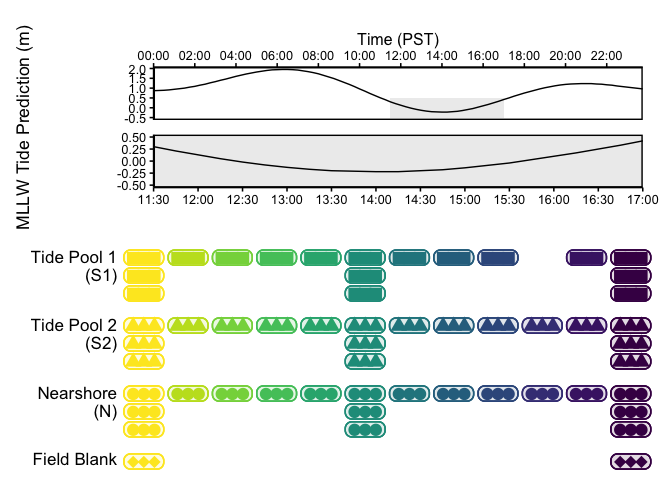

```r
##IN PROGRESS

data_forchart = amp$metadata[!is.na(amp$metadata$Time),]

data_forchart = data_forchart %>% group_by(SiteByTime) %>% mutate(chart_num = ceiling(row_number()/3))

data_forchart$datetime <- lubridate::ymd_hm(paste("2022/01/28", data_forchart$Time), tz = "US/Pacific")
data_forchart$LocNumTime = as.factor(paste(data_forchart$Location, data_forchart$chart_num, data_forchart$Time))


facet.labs =  c("Tide Pool 1\n (S1)", "Tide Pool 2\n (S2)", "Nearshore\n (N)", "Field Blank")
names(facet.labs) = c("S1", "S2", "N", "FB")

data_forchart$Location= factor(data_forchart$Location, levels=c("S1", "S2", "N", "FB"))
data_forchart$chart_num= factor(data_forchart$chart_num, levels=c("3", "2", "1"))

sample_schema = ggplot(data = data_forchart, aes(x = Time, y = chart_num, shape = Location,
                                 color = Time,
                                 fill = after_scale(alpha(colour, 0.05)))) +
  geom_beeswarm(cex = 2, size = 4) +
  geom_box(aes(xmin = after_stat(x) - 0.45,
               xmax = after_stat(x) + 0.45,
               ymin = after_stat(y) - 0.4,
               ymax = after_stat(y) + 0.45),
           radius = unit(5, "pt")) +
  scale_shape_manual(values = c(15, 17, 16, 18)) +
  scale_color_viridis_d(direction = -1) +
  facet_grid(Location ~., scales = "free_y", space = "free_y",
             switch = "y", labeller = labeller(Location = facet.labs)) +
  theme_void(base_size = 16) +
  theme(legend.position = "none",
        strip.text.y.left = element_text(angle = 0, hjust = 1, vjust = .9))


graph = sample_schema

filename = paste("sample_schema_full.pdf")
  path = paste("Figures/PowerPointFigure/", filename)
  pdf(path, width = 13, height = 4.3)
  print(graph)
  dev.off()

  graph$layers[[1]] <- NULL

  alpha=c(0,0,0,0,0,0,0,0,0,0,0,0)

for (i in 1:12) {
  alpha[i] = 1
  graph <- graph +
    scale_color_viridis_d(direction = -1, alpha = alpha) +
     scale_fill_viridis_d(direction = -1, alpha = alpha)
  filename = paste("sample_schema", i, ".pdf")
  path = paste("Figures/PowerPointFigure/", filename)
  pdf(path, width = 13, height = 4.3)
  print(graph)
  dev.off()
}


##Still need to line up axes between two plots, probably by changing date format for both
##Still need to add field blank to plots
p_patch/sample_schema
```

```r
#OLD VERSION

#sample_schema = ggplot(data = data_forchart, aes(x = datetime, y = chart_num, shape = Location, color = Time, fill = Time)) +
   #facet_grid(Location ~., scales = "free_y", space = "free_y", switch = "y", labeller = labeller(Location = facet.labs)) +
  #geom_point(position = position_dodge2(width = 1)) +
  #geom_beeswarm(cex= 2, size = 3) +
  #geom_mark_rect(aes(group = LocNumTime)) +
  #coord_cartesian(xlim = c(xmin, xmax)) +
  #scale_shape_manual(values = c(15, 17, 16)) +
  #viridis::scale_color_viridis(discrete=TRUE, begin = 0, end = .97, direction = -1) +
  #viridis::scale_fill_viridis(discrete=TRUE, begin = 0, end = .97, direction = -1) +
  #theme_void(base_size = 16) +
  #theme(legend.position = "none") +
#theme(strip.text.y.left = element_text(angle = 0, hjust = 1, vjust = .9))
```

```r
#Gather information about processed Anacapa Toolkit

processed_ASVs = nrow(data_amp$abund)
processed_reads = sum(data_amp$abund)

#Create a phyloseq object where all samples are combined into one
total = as.data.frame(rowSums(data_amp$abund))
physeq_summed = amp_to_phyloseq(NULL, total, data_amp$tax[,1:7], NULL)

#Summarize the number of unassigned ASVs
kingdom = as.data.frame(tax_table(physeq_summed)[,1])
unassigned_ASVs = kingdom %>% group_by(Kingdom) %>% summarise(n = n()) %>% mutate (freq = n / sum(n))

#Summarize the number of unique phyla
unique_phyla = unique(tax_table(physeq_summed)[,2])
unique_phyla = unique_phyla[unique_phyla != ""]
phyla = length(unique_phyla)

#Summarize the number of unique classes
unique_class = unique(tax_table(physeq_summed)[,3])
unique_class = unique_class[unique_class != ""]
class = length(unique_class)

#Summarize the number of unique orders
unique_order = unique(tax_table(physeq_summed)[,4])
unique_order = unique_order[unique_order != ""]
order = length(unique_order)

#Summarize the number of unique families
unique_family = unique(tax_table(physeq_summed)[,5])
unique_family = unique_family[unique_family != ""]
family = length(unique_family)

#Summarize the number of unique genera
unique_genus = unique(tax_table(physeq_summed)[,6])
unique_genus = unique_genus[unique_genus != ""]
genus = length(unique_genus)

#Summarize the number of unique species
unique_species = unique(tax_table(physeq_summed)[,7])
unique_species = unique_species[unique_species != ""]
species = length(unique_species)

#Remove all unclassified ASVs and condense to phylum level
physeq_totalreads = tax_glom(physeq_summed, taxrank="Phylum", NArm=TRUE)
Phyla_Reads = data.frame(Phyla = tax_table(physeq_totalreads)[,2],
                         Reads = rowSums(otu_table(physeq_totalreads)))
```

```r
#This chunk takes a long time to run
#TO-DO: figure out how to set this up with future or callr

#Create list of identified species
species_list = unique(data_amp$tax$Species)
species_list = remove_NCBInums(species_list)
species_list = species_list[species_list != ""]
species_list = sub("_", "-", species_list) #to address Pseudo_nitzchia error


#Standardize species names against GBIF backbone
species_GBIF = name_backbone_checklist(species_list)
species_standardized = species_GBIF$species[!is.na(species_GBIF$species)]
species_both = species_GBIF[c("species", "verbatim_name")]


##Core GBIF checking function
distribution_check <- function(small_bound, big_bound, species, min_records, efficiency) {

  ##Function that checks GBIF given a particular geographic region
  boundary_function <- function(species, bounds) {
    no_data = c()
    confirmed = c()
    for (i in species) {
      print(i)
      occ = occ(query = i, geometry = bounds, from = 'gbif', limit = min_records, has_coords = TRUE, gbifopts = list(hasGeospatialIssue = FALSE))
      occ.df = occ2df(occ)
      if (nrow(occ.df) >= min_records) {
        confirmed = append(confirmed, i)
      } else {
        no_data = append(no_data, i)
      }
    }
    return(list(no_data = no_data, confirmed = confirmed))
  }

  ##Function that checks GBIF to confirm whether a particular location is within the range of observations
  range_function <- function(species){
    CC.confirmed = c()
    CC.not_confirmed = c()
    CC.no_data = c()
    limits = c(10, 100, 1000, 10000)

    for (i in species) {
      track = 0
      for (l in limits) {
        print(i)
        print (l)
        occ = occ(i, from = 'gbif', limit = l, has_coords = TRUE, gbifopts = list(hasGeospatialIssue = FALSE))
        occ.df = occ2df(occ)
        if (nrow(occ.df) < min_records) {
          CC.no_data = append(CC.no_data, i)
          print("no data")
          track = 1
          break
        }
        bb_occ = sp::bbox(cbind(occ.df$longitude, occ.df$latitude))
        if (bb_occ['x', 'min'] < small_bound[1] & bb_occ['x', 'max'] >small_bound[1] & bb_occ['y', 'min'] <small_bound[4] & bb_occ['y', 'max'] >small_bound[4]) {
          CC.confirmed = append(CC.confirmed, i)
          print("confirmed")
          track = 1
          break
        }
        if(nrow(occ.df) < l) {
          CC.not_confirmed = append(CC.not_confirmed, i)
          print("not confirmed")
          track = 1
          break
        }
      }
      if(track == 0) {
        CC.not_confirmed = append(CC.not_confirmed, i)
        print("not confirmed")
      }
    }
    return(list(no_data = CC.no_data, not_confirmed = CC.not_confirmed, confirmed = CC.confirmed))
  }


  #Actual Steps
  PP = boundary_function(species, small_bound)

  if(efficiency == TRUE) {
    CC = boundary_function(PP[["no_data"]], big_bound)
  } else {
    CC = boundary_function(species, big_bound)
  }

  if(efficiency == TRUE) {
    range_confirmed = range_function(CC[["confirmed"]])
    range_unconfirmed = range_function(CC[["not_confirmed"]])
    return(list(PP, CC, range_confirmed, range_unconfirmed))
  } else {
    range = range_function(species)
    return(list(PP, CC, range))
  }
}



#Get the California Current System shape

CC_shape = mr_features_get(type = "MarineRegions:lme", featureID = "lme.10", format = "json")

#check that it's the right polygon
class(CC_shape) <- "mr_geojson"
CC_shape = mr_as_wkt(CC_shape)
pnt <- st_as_sfc(CC_shape, crs = 4326)
mapview(pnt)
```

[interactive chart not shown]

```r
#Simplify the polygon for use with GBIF
CC_shape_sp = st_transform(pnt, crs = '+proj=aeqd +lat_0=53.6 +lon_0=12.7')
mapview(CC_shape_sp)
```

[interactive chart not shown]

```r
CC_shape_sp = st_simplify(CC_shape_sp, preserveTopology = FALSE, dTolerance=10000)
CC_shape_sp = st_transform(CC_shape_sp, crs = 4326)
mapview(CC_shape_sp)
```

[interactive chart not shown]

```r
distribution = distribution_check(c(-122.50, 37.49, -122.49, 37.50), CC_shape_sp, species_standardized, 5, FALSE)
```

```r
d = distribution
PP = d[[1]]$confirmed
CC = d[[2]]$confirmed
range = d[[3]]$confirmed
no_data = d[[3]]$no_data

df_PP = c()
df_CC = c()
df_range = c()
df_no_data = c()
df_not_in_GBIF = c()


for (s in species_both$species) {
  if(is.na(s)) {
    df_not_in_GBIF = append(df_not_in_GBIF, TRUE)
    df_PP = append(df_PP, NA)
    df_CC = append(df_CC, NA)
    df_range = append(df_range, NA)
    df_no_data = append(df_no_data, NA)
    next
  } else {
    df_not_in_GBIF = append(df_not_in_GBIF, FALSE)
  }

  if(s %in% PP) {
    df_PP = append(df_PP, TRUE)
  } else {
    df_PP = append(df_PP, FALSE)
  }

  if(s %in% CC) {
    df_CC = append(df_CC, TRUE)
  } else {
    df_CC = append(df_CC, FALSE)
  }

  if(s %in% range) {
    df_range = append(df_range, TRUE)
  } else {
    df_range = append(df_range, FALSE)
  }

  if(s %in% no_data) {
    df_no_data = append(df_no_data, TRUE)
  } else {
    df_no_data = append(df_no_data, FALSE)
  }

}

GBIF_summary = data.frame(Species = species_both$verbatim_name,
                     GBIFSpecies = species_both$species,
                     PillarPointOccurrence = df_PP,
                     CCSOccurrence = df_CC,
                     Range = df_range,
                     NoData = df_no_data,
                     NotInGBIF = df_not_in_GBIF)

print(GBIF_summary %>% group_by(across(PillarPointOccurrence:NotInGBIF)) %>% summarise(count=n()))
```

```
## # A tibble: 7 × 6
## # Groups:   PillarPointOccurrence, CCSOccurrence, Range, NoData [7]
##   PillarPointOccurrence CCSOccurrence Range NoData NotInGBIF count
##   <lgl>                 <lgl>         <lgl> <lgl>  <lgl>     <int>
## 1 FALSE                 FALSE         FALSE FALSE  FALSE        40
## 2 FALSE                 FALSE         FALSE TRUE   FALSE        17
## 3 FALSE                 FALSE         TRUE  FALSE  FALSE        37
## 4 FALSE                 TRUE          FALSE FALSE  FALSE        12
## 5 FALSE                 TRUE          TRUE  FALSE  FALSE       189
## 6 TRUE                  TRUE          TRUE  FALSE  FALSE       100
## 7 NA                    NA            NA    NA     TRUE         20
```

```r
known_summary = GBIF_summary %>% filter(!is.na(GBIFSpecies)) %>% summarise(count = sum(Range == TRUE & CCSOccurrence == TRUE))

##Add code to calculate the various percentages used in the text

write.csv(GBIF_summary, "Data/Analysis Products/RangeAnalysis.csv", row.names=TRUE)
```

| count |
| --- |
| 289 |

```r
 #merge all samples together
  #make abundance of each one
  #glom by phylum

  physeq_totalASVs = physeq_summed

  otu_table(physeq_totalASVs)[otu_table(physeq_totalASVs)>0] <- 1
  physeq_totalASVs = tax_glom(physeq_totalASVs, taxrank="Phylum", NArm=TRUE)


  Phyla_ASVs = data.frame(Phyla = tax_table(physeq_totalASVs)[,2], ASVs = rowSums(otu_table(physeq_totalASVs)))


  physeq_speciesbyphyla = physeq_summed
  physeq_speciesbytaxa = tax_glom(physeq_summed, taxrank="Species", NArm=TRUE)
  otu_table(physeq_speciesbytaxa)[otu_table(physeq_speciesbytaxa)>0] <- 1
  physeq_speciesbytaxa = tax_glom(physeq_speciesbytaxa, taxrank="Phylum", NArm=TRUE)

  Phyla_Species =  data.frame(Phyla = tax_table(physeq_speciesbytaxa)[,2], Species = rowSums(otu_table(physeq_speciesbytaxa)))


  list = list(Phyla_Reads, Phyla_ASVs, Phyla_Species)
  full = list %>% reduce(full_join, by='Phylum')
  full[is.na(full)] <- 0


  full_sorted = full[order(-full$Reads),]

  full_sorted = full_sorted %>%
    mutate(Reads_Percent = scales::label_percent()(Reads/sum(Reads))) %>%
    mutate(ASVs_Percent = scales::label_percent()(ASVs/sum(ASVs))) %>%
    mutate(Species_Percent = scales::label_percent()(Species/sum(Species)))

  full_sorted$Phylum = remove_NCBInums(full_sorted$Phylum)
  full_sorted$Phylum = str_replace(full_sorted$Phylum, "phylum_", "Class: ")

  col_order = c("Phylum", "Reads", "Reads_Percent", "ASVs", "ASVs_Percent", "Species", "Species_Percent")

  full_sorted = full_sorted[,col_order]

  full_sorted
```

|  | Phylum | Reads | Reads_Percent | ASVs | ASVs_Percent | Species | Species_Percent |
| --- | --- | --- | --- | --- | --- | --- | --- |
| 3 | Rhodophyta | 532203 | 36.77767% | 615 | 20.847% | 97 | 23.37% |
| 1 | Chlorophyta | 276017 | 19.07404% | 189 | 6.407% | 6 | 1.45% |
| 2 | Class: Dinophyceae | 169579 | 11.71869% | 120 | 4.068% | 8 | 1.93% |
| 6 | Arthropoda | 136328 | 9.42089% | 423 | 14.339% | 48 | 11.57% |
| 4 | Chordata | 81310 | 5.61889% | 173 | 5.864% | 39 | 9.40% |
| 7 | Annelida | 74621 | 5.15665% | 477 | 16.169% | 50 | 12.05% |
| 5 | Cnidaria | 62818 | 4.34101% | 153 | 5.186% | 22 | 5.30% |
| 8 | Class: Phaeophyceae | 42314 | 2.92409% | 144 | 4.881% | 24 | 5.78% |
| 9 | Mollusca | 28102 | 1.94198% | 267 | 9.051% | 43 | 10.36% |
| 10 | Echinodermata | 13406 | 0.92642% | 90 | 3.051% | 14 | 3.37% |

[output cut: 18 more lines]

```r
  write.csv(full_sorted, "Data/Analysis Products/TaxonDiversity.csv", row.names=TRUE)
```

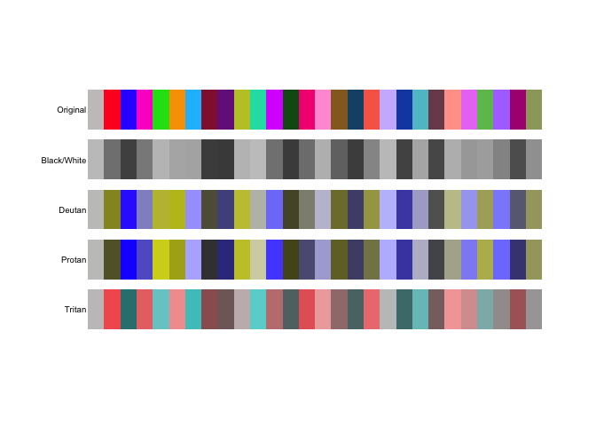

```r
options(getClass.msg=FALSE)

#Aggregate to species assignment and remove the NCBI identifiers
pt_physeq = tax_glom(data_physeq, taxrank="Species", NArm=FALSE)
tax_table(pt_physeq) = tax_table(pt_physeq)[!tax_table(pt_physeq)[,"Kingdom"]==""]

tax_table(pt_physeq)[tax_table(pt_physeq)==""] = NA
numbers = sub(".*_","", tax_table(pt_physeq))

taxa = apply(numbers, 1, function(x) tail(na.omit(x), 1))

tax_table(pt_physeq) = remove_NCBInums(tax_table(pt_physeq))


taxa_classification = classification(taxa, db = "ncbi")


taxa_tree = class2tree(taxa_classification, check = TRUE)

#Change the tip labels to match phyloseq objects (code only works if order is the same)
taxa_tree$phylo$tip.label = row.names(tax_table(pt_physeq))


phyla = unique(tax_table(pt_physeq)[,"Phylum"])


phyla_nodes = data.frame("node_phylum" = c(), "node" = c())
phyla_nodes_secondary = data.frame("node_phylum" = c(), "tips" = c())

for (x in phyla) {
  OTUs = na.omit(row.names(tax_table(pt_physeq))[tax_table(pt_physeq)[,"Phylum"] == x])
  OTUs = as.vector(OTUs)
  num = ape::getMRCA(taxa_tree$phylo, tip = OTUs)
  if (is.null(num)) {
    nodes = as_tibble(taxa_tree$phylo)
    num = nodes$node[nodes$label == OTUs]
  }
  df = data.frame("node_phylum" = c(x), "node" = c(num))
  phyla_nodes = rbind(phyla_nodes, df)

  if (length(OTUs) <6) {
    for (y in OTUs) {
      df2 = data.frame("node_phylum" = c(x), "tips" = c(y))
      phyla_nodes_secondary = rbind(phyla_nodes_secondary, df2)
    }
  }
}




pt_physeq = merge_phyloseq(pt_physeq, taxa_tree$phylo)


#Use Polychrome package to create a good color palette for the number of phyla
set.seed(567629)
colors = createPalette(28, c("#FFFFFF"), range = c(30, 80), target = c("normal", "protanope", "deuteranope", "tritanope"))

#Check whether the given order of colors has good contrast for different forms of colorblindness
pal.safe(colors)
```

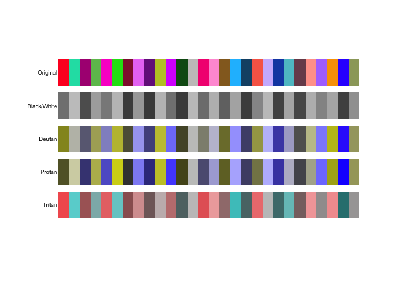

```r
#Manually re-order the colors to ensure there is good contrast between adjacent colors
colors_ordered = colors[c('NC2',
                          'NC11',
                          'NC27',
                          'NC25',
                          'NC4',
                          'NC5',
                          'NC8',
                          'NC24',
                          'NC9',
                          'NC10',
                          'NC12',
                          'NC13',
                          'NC1',
                          'NC14',
                          'NC15',
                          'NC16',
                          'NC7',
                          'NC17',
                          'NC18',
                          'NC19',
                          'NC20',
                          'NC21',
                          'NC22',
                          'NC23',
                          'NC26',
                          'NC6',
                          'NC3',
                          'NC28')]

#Confirm that the new order works well
pal.safe(colors_ordered)
```

```r
#Create ggtree
p <- ggtree(pt_physeq,  layout = "circular")

ordered_names = get_taxa_name(p)
ordered_names = unique(ordered_names)
ordered_names[match(rownames(tax_table(pt_physeq)), ordered_names)] = tax_table(pt_physeq)[,"Phylum"]
ordered_names = unique(ordered_names)

names(colors_ordered) = ordered_names

p = p + geom_fruit(geom = geom_tile, mapping = aes(fill = Phylum), width = 3, show.legend = FALSE)  + scale_fill_manual(values = colors_ordered) +scale_color_manual(values = colors_ordered)

p = p +  geom_fruit(data=phyla_nodes_secondary, geom = geom_tile, mapping = aes(y = tips, fill = node_phylum), width = 6, show.legend = FALSE)

p = p + geom_hilight(data=phyla_nodes, mapping=aes(node = node, fill = node_phylum), show.legend = FALSE)

p = p + geom_cladelab(data=phyla_nodes, mapping=aes(node=node, label= node_phylum), geom = "text", angle = "auto", offset = 5, fontsize=2, barcolor=NA, show.legend = FALSE)

p = p +
  theme(
    panel.background = element_rect(fill='transparent'),
    plot.background = element_rect(fill='transparent', color=NA),
    panel.grid.major = element_blank(),
    panel.grid.minor = element_blank(),
    legend.background = element_rect(fill='transparent'),
    legend.box.background = element_rect(fill='transparent')
  )

ggsave(
  "Figures/Figure4.pdf",
  plot = p,
  dpi = 300,
  bg='transparent')
```

```r
p <- ggtree(pt_physeq,  layout = "rectangular")
```

[output not shown]

[output not shown]

[output not shown]

[output not shown]

[output not shown]

[output not shown]

[output not shown]

[output not shown]

[output not shown]

[output not shown]

[output not shown]

[output not shown]

[output not shown]

[output not shown]

[output not shown]

```r
ordered_names = get_taxa_name(p)
ordered_names = unique(ordered_names)
ordered_names[match(rownames(tax_table(pt_physeq)), ordered_names)] = tax_table(pt_physeq)[,"Phylum"]
ordered_names = unique(ordered_names)

names(colors_ordered) = ordered_names

p = p + geom_fruit(geom = geom_tile, mapping = aes(fill = Phylum), width = 3, show.legend = FALSE)  + scale_fill_manual(values = colors_ordered) +scale_color_manual(values = colors_ordered)

p = p + geom_hilight(data=phyla_nodes, mapping=aes(node = node, fill = node_phylum), show.legend = FALSE)



p = p +
  theme(
    panel.background = element_rect(fill='transparent'),
    plot.background = element_rect(fill='transparent', color=NA),
    panel.grid.major = element_blank(),
    panel.grid.minor = element_blank(),
    legend.background = element_rect(fill='transparent'),
    legend.box.background = element_rect(fill='transparent')
  )

ggsave(
  "Figures/PowerPointFigure/phylo.pdf",
  plot = p,
  width = 4.49,
  height = 7.06,
  dpi = 300,
  bg='transparent')
```

#### 3.2 Individual-Level Differences Between Locations

```r
#Subset ampvis2 data by location

amp_S1 = amp_filter_samples(data_amp, Location %in% c("S1"))
```

```
## 108 samples and 14365 OTUs have been filtered
## Before: 159 samples and 27038 OTUs
## After: 51 samples and 12673 OTUs
```

```r
amp_S2 = amp_filter_samples(data_amp, Location %in% c("S2"))
```

```
## 105 samples and 16586 OTUs have been filtered
## Before: 159 samples and 27038 OTUs
## After: 54 samples and 10452 OTUs
```

```r
amp_N = amp_filter_samples(data_amp, Location %in% c("N"))
```

```
## 105 samples and 15230 OTUs have been filtered
## Before: 159 samples and 27038 OTUs
## After: 54 samples and 11808 OTUs
```

```r
#List the unique taxa at each location

S1_taxa = unique(amp_S1$tax$Species)
S1_taxa = S1_taxa[S1_taxa != ""]
S2_taxa = unique(amp_S2$tax$Species)
S2_taxa = S2_taxa[S2_taxa != ""]
N_taxa = unique(amp_N$tax$Species)
N_taxa = N_taxa[N_taxa != ""]

#List the unique ASVs at each locaton

S1_ASV = unique(amp_S1$tax$OTU)
S2_ASV = unique(amp_S2$tax$OTU)
N_ASV = unique(amp_N$tax$OTU)


#Using eulerr, create euler diagrams for taxa and ASVs


add_quantity_line_break = function(v) {
  tags <- v$children$canvas.grob$children$diagram.grob.1$children$tags$children

  tags <- do.call(grid::gList, lapply(tags, function(x) {
    x$children[[2]]$label <- sub(" \\%)", "%)", x$children[[2]]$label)
    before = sub("\\(.*", "", x$children[[2]]$label)
    after = gsub(".*\\(", "(", x$children[[2]]$label)
    italics = bquote(atop(.(before),italic(.(after))))
    x$children[[2]]$label <- italics
    x$children[[2]]$just <- NULL
    x}))

  v$children$canvas.grob$children$diagram.grob.1$children$tags <- tags

  return(v)
}


E_taxa <- euler(list(S1 = S1_taxa, S2 = S2_taxa, N = N_taxa), shape = "ellipse")
E_taxa_plot = plot(E_taxa, quantities = list(type = c("counts", "percent"), cex=2), legend = list(side ="right", nrow = 1, ncol = 3, cex = 2.5))
E_taxa_plot = add_quantity_line_break(E_taxa_plot)


E_ASV <- euler(list(S1 = S1_ASV, S2 = S2_ASV, N = N_ASV), shape="ellipse")
E_ASV_plot = plot(E_ASV, quantities = list(type = c("counts", "percent"), cex=2), legend = list(side ="right", nrow = 1, ncol = 3, cex = 2.5))
E_ASV_plot = add_quantity_line_break(E_ASV_plot)
```

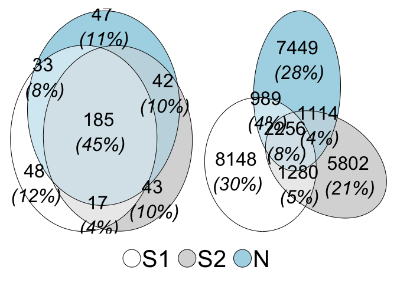

```r
(wrap_elements(panel = E_taxa_plot$children$canvas.grob) + wrap_elements (panel = E_ASV_plot$children$canvas.grob)) / wrap_elements(panel = E_taxa_plot$children$legend.grob) + plot_layout(heights = c(7,1))
```

```r
#Function for creating indicator species heatmap from physeq data

indicator_heatmap <- function(physeq, asv) {

  #If analyzing by taxa, remove all unclassified ASVs and condense to species assignments
  if(asv == FALSE) {
    physeq = tax_glom(physeq, taxrank="Species", NArm=TRUE)
    tax_table(physeq) = gsub("\\_.*","",tax_table(physeq))
  }

  #Convert to presence/absence data
  otu_table(physeq)[otu_table(physeq) >0] <- 1


  #Use indicspecies package to get top taxa
  indval = multipatt(t(otu_table(physeq)),t(sample_data(physeq)[,"Location"]), control = how(nperm=999), duleg = TRUE)
  top_N = rownames(indval$sign %>% filter(p.value < 0.05) %>% filter(s.N == 1)  %>% filter(stat > .7))
  top_S1 = rownames(indval$sign %>% filter(p.value < 0.05) %>% filter(s.S1 == 1)  %>% filter(stat > .7))
  top_S2 = rownames(indval$sign %>% filter(p.value < 0.05) %>% filter(s.S2 == 1)  %>% filter(stat > .7))

  indicators_all = c(top_N, top_S1, top_S2)

  #Merge samples by site/time before plotting
  physeq_merge = merge_samples(physeq, "SiteByTime")

  #Update metadata accordingly
  updated_metadata = as.matrix(sample_data(physeq)[, c("SiteByTime", "Time", "Location", "T", "S")])
  updated_metadata = as.data.frame(updated_metadata)
  updated_metadata$SiteByTime = as.factor(updated_metadata$SiteByTime)
  updated_metadata$Time = as.factor(updated_metadata$Time)
  updated_metadata$Location = as.factor(updated_metadata$Location)
  updated_metadata = distinct(updated_metadata)
  rownames(updated_metadata) = updated_metadata[,'SiteByTime']
  sample_data(physeq_merge) <- sample_data(updated_metadata)

  #Divide all merged samples by the number of samples they represent
  otu_table(physeq_merge) = otu_table(physeq_merge)/3

  otu_table(physeq_merge)[grepl('11:30', rownames(otu_table(physeq_merge)))] = otu_table(physeq_merge)[grepl('11:30', rownames(otu_table(physeq_merge)))]/3

  otu_table(physeq_merge)[grepl('14:00', rownames(otu_table(physeq_merge)))] = otu_table(physeq_merge)[grepl('14:00', rownames(otu_table(physeq_merge)))]/3

   otu_table(physeq_merge)[grepl('17:00', rownames(otu_table(physeq_merge)))] = otu_table(physeq_merge)[grepl('17:00', rownames(otu_table(physeq_merge)))]/3

  #Add labels to the indicator species for plotting
  indicators_only <-prune_taxa(colnames(otu_table(physeq_merge)) %in% indicators_all, physeq_merge)

  add_indicator_label <- function(X) {
    if (X %in% top_N) { return("N")}
    else if (X %in% top_S1) { return("S1")}
    else if (X %in% top_S2) {return ("S2")}
    else {return("NA")}
  }

  indicators<- sapply(rownames(tax_table(indicators_only)), add_indicator_label)

  tax_table(indicators_only) = cbind(tax_table(indicators_only), indicators)

  #Plot
  plot = plot_heatmap(indicators_only,
                      method = NULL,
                      distance = NULL,
                      trans = NULL,
                      taxa.order = rev(indicators_all),
                      taxa.label = "Species",
                      sample.label = "Time",
                      sample.order = "Time") +
    facet_grid(factor(indicators, levels=c('S1', 'S2', 'N'))~factor(Location, levels=c('S1', 'S2', 'N')),
               scales="free",
               space = "free",
               switch = "y") +
    scale_fill_gradient(low = "black", high = "#B5D7E4") +
    theme_grey(base_size = 12) +
    theme(plot.title = element_text(hjust = 0.5)) +
    theme(axis.text.x = element_text(angle = 45, vjust = 1, hjust=1)) +
    theme(strip.placement = "outside", axis.text.x=element_text(size=12))  +
    theme(strip.text = element_text(size = rel(1))) +
    #theme(legend.text=element_text(size=12), legend.key.height = unit(1.5, "cm")) +
    theme(panel.background = element_blank(), panel.grid.major = element_blank()) +
    labs(fill = "Proportion of \nPositive Detects", title = "Locations") +
    theme(axis.ticks = element_line(color = "black"),
          axis.text.y = element_text(color="black", face = "italic"),
          axis.text.x = element_text(color="black"))

  plot$scales$scales[[2]]$name <- "Indicators"

  return(list(plot = plot,
              top_N = top_N,
              top_S1 = top_S1,
              top_S2 = top_S2,
              all_indicators = indicators_all,
              full_output = indval))
}

heatmap_taxa = indicator_heatmap(data_physeq, FALSE)
heatmap_ASV = indicator_heatmap(data_physeq, TRUE)
indicator_ASVs = data_amp$tax[heatmap_ASV$all_indicators,]
unassigned_indicator_ASVs = indicator_ASVs %>% group_by(Kingdom) %>% summarise(n = n()) %>% mutate (freq = n / sum(n))
```

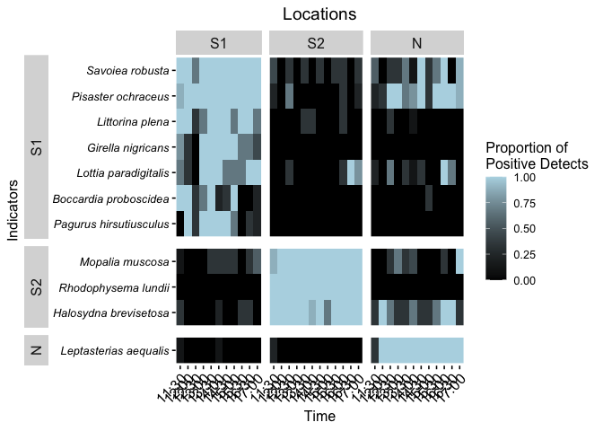

```r
heatmap_taxa$plot
```

```r
path = "Figures/Figure6.png"
  ggsave(filename = path, plot = heatmap_taxa$plot, device = "png", width = 169, height = 120, units = "mm", dpi = 600)

  #adjust legend position
```

```r
 graph = heatmap_taxa$plot

  path = "Figures/PowerPointFigure/indicator_figure.png"
  ggsave(filename = path, plot = graph, width = 13, height = 6.69)
```

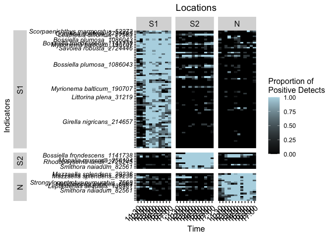

```r
heatmap_ASV$plot
```

#### 3.3. Community-Level Differences between Locations

```r
#Calculate Jaccard dissimilarity matrices
jaccard_full = vegdist(t(data_amp$abund), binary = TRUE, method = "jaccard")
jaccard_taxa = vegdist(t(data_amp_taxa$abund), binary = TRUE, method = "jaccard")
```

```r
set.seed(0)

#PERMANOVA on full data set
permutest(betadisper(jaccard_full, data_amp$metadata$Location))
```

```
##
## Permutation test for homogeneity of multivariate dispersions
## Permutation: free
## Number of permutations: 999
##
## Response: Distances
##            Df   Sum Sq    Mean Sq      F N.Perm Pr(>F)
## Groups      2 0.002340 0.00117003 2.9267    999  0.061 .
## Residuals 156 0.062365 0.00039977
## ---
## Signif. codes:  0 '***' 0.001 '**' 0.01 '*' 0.05 '.' 0.1 ' ' 1
```

```r
adonis2(jaccard_full ~ Location + Time + Dereplicated_Sample_Name , data = data_amp$metadata)
```

|  | Df | SumOfSqs | R2 | F | Pr(>F) |
| --- | --- | --- | --- | --- | --- |
| Location | 2 | 5.173470 | 0.08665478 | 9.045805 | 0.001 |
| Time | 11 | 7.305617 | 0.12236788 | 2.322520 | 0.001 |
| Dereplicated_Sample_Name | 39 | 16.911268 | 0.28326096 | 1.516376 | 0.001 |
| Residual | 106 | 30.311722 | 0.50771638 | NA | NA |
| Total | 158 | 59.702077 | 1.00000000 | NA | NA |

```r
#PERMANOVA on taxa data set
permutest(betadisper(jaccard_taxa, data_amp_taxa$metadata$Location))
```

```
##
## Permutation test for homogeneity of multivariate dispersions
## Permutation: free
## Number of permutations: 999
##
## Response: Distances
##            Df  Sum Sq    Mean Sq      F N.Perm Pr(>F)
## Groups      2 0.00061 0.00030272 0.1364    999  0.894
## Residuals 156 0.34626 0.00221963
```

```r
adonis2(jaccard_taxa ~ Location + Time + Dereplicated_Sample_Name, data = data_amp_taxa$metadata)
```

|  | Df | SumOfSqs | R2 | F | Pr(>F) |
| --- | --- | --- | --- | --- | --- |
| Location | 2 | 0.6864437 | 0.02383518 | 3.345916 | 0.001 |
| Time | 11 | 3.7239838 | 0.12930680 | 3.300314 | 0.001 |
| Dereplicated_Sample_Name | 39 | 13.5157606 | 0.46930381 | 3.378439 | 0.001 |
| Residual | 106 | 10.8734092 | 0.37755421 | NA | NA |
| Total | 158 | 28.7995973 | 1.00000000 | NA | NA |

[figure not shown]

[figure not shown]

[figure not shown]

[figure not shown]

[figure not shown]

[figure not shown]

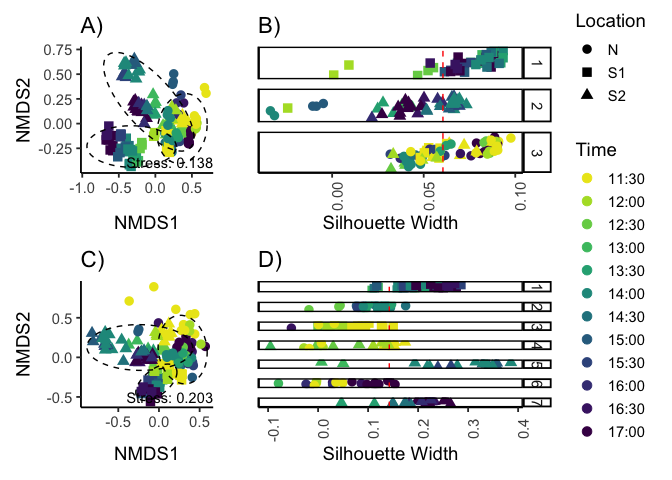

```r
(NMDS_PAM_full$NMDS + theme(legend.position = "none") + ggtitle("A)")) +
  (NMDS_PAM_full$PAM  + theme(legend.position = "none") + ggtitle("B)")) +
  (NMDS_PAM_taxa$NMDS + theme(legend.position = "none") + ggtitle("C)")) +
  (NMDS_PAM_taxa$PAM + ggtitle("D)")) +
  plot_layout(guides = 'collect', widths = c(1,2))
```

```r
#Add figuring saving
```

```r
distmat <- as.matrix(jaccard_full)

#Calculate Pairwise Dissimilarity Values Within and Across Sites

Jaccard = c()
Combo = c()
Time = c()
summary = data.frame(Jaccard, Combo, Time)

one = c("S1", "S2", "N", "S1", "S2", "S1")
one_names = c("S1", "S2", "N", "S1", "S2", "S1")
two = c("S1", "S2", "N", "N", "N", "S2")
two_names = c("S1", "S2", "N", "N", "N", "S2")

for(x in levels(data_amp$metadata$Time)){
  subset = filter(data_amp$metadata, data_amp$metadata$Time == x)

  for(i in 1: length(one)) {
    name = paste(one_names[i], two_names[i], sep = ":")
    data = distmat[subset$X[subset$Location == one[i]], subset$X[subset$Location == two[i]]]
    Jaccard = vector()

    if (!(0 %in% dim(data))) {
      for (row in 1:nrow(data)) {
        for (col in 1:ncol(data)){
           if (col > row) {
            Jaccard = c(Jaccard, data[row,col])
          }
        }
      }
    }
    Combo <- rep(name, length(Jaccard))
    Time <- rep(x, length(Jaccard))

    summary <- rbind(summary, data.frame(Jaccard, Combo, Time))
  }
}


##PLOTTING

#Define palette for colors and fills
colors = turbo(8)

palette = c("Within Site" = "#30123BFF",
            "S1:N" ="#1AE4B6FF" ,
            "S2:N" = "#FABA39FF",
            "S1:S2" = "#7A0403FF")

fill_palette = c("Within Site" = "#30123B20",
                 "S1:N" ="#1AE4B620",
            "S2:N" = "#FABA3920",
            "S1:S2" = "#7A040320")


#WITHIN SITE COMBINED

summary$Combo2 <- summary$Combo
summary$Combo2[summary$Combo2 == "S1:S1"] = "Within Site"
summary$Combo2[summary$Combo2 == "S2:S2"] = "Within Site"
summary$Combo2[summary$Combo2 == "N:N"] = "Within Site"

stats = summary %>% filter(Combo2 == "Within Site") %>% summarize(mean = mean(Jaccard), max = max(Jaccard))


g2.5 = ggplot(summary, aes(x = Time,
                           y = Jaccard,
                           color = factor(Combo2, level = c("Within Site", "S1:N", "S2:N", "S1:S2")),
                           fill = factor(Combo2, level = c("Within Site", "S1:N", "S2:N", "S1:S2")))) +
  geom_boxplot(position = position_dodge(.5, preserve = "single")) +
  geom_point(position = position_jitterdodge(dodge.width = .5), alpha=0.2) +
  scale_color_manual(values = palette, name = "Site Pairings") +
  scale_fill_manual(values = fill_palette, name = "Site Pairings") +
  geom_hline(yintercept = stats$mean, color = palette["Within Site"] ) +
  ylab("Jaccard Dissimilarity") +
  coord_cartesian(expand = 0, clip = "off") +
  geom_text(aes(max(Time),
                stats$mean,
                label = "Mean Dissimilarity\n  Within Sites",
                hjust = -.2),
            color = palette["Within Site"],
            show.legend = FALSE,
            check_overlap = TRUE) +
  theme_classic(base_size = 12) +
  theme(axis.ticks = element_line(color = "black"),
        axis.text.y = element_text(color="black"),
        axis.text.x = element_text(color="black")) +
  theme(legend.position="right",legend.justification="top")
```

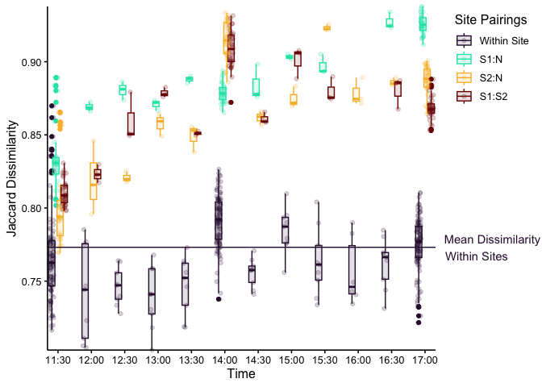

```r
g2.5
```

```r
path = "Figures/Figure8.pdf"
  ggsave(filename = path, plot = g2.5, device = "pdf", width = 169, height = 120, units = "mm", dpi = 600)
```

#### 3.4. Ecological Significance

```r
#NOT DONE YET

S1_unique = setdiff(S1_taxa, union(S2_taxa,N_taxa) )
S2_unique = setdiff(S2_taxa, union(S1_taxa,N_taxa) )
N_unique = setdiff(N_taxa, union(S2_taxa,S1_taxa) )


S1 = data.frame(list(Species = remove_NCBInums(S1_unique), Unique = "S1"))
S2 = data.frame(list(Species = remove_NCBInums(S2_unique), Unique = "S2"))
N = data.frame(list(Species = remove_NCBInums(N_unique), Unique = "N"))
unique = rbind(S1, S2, N)

S1_i = data.frame(list(Species = remove_NCBInums(data_amp$tax$Species[rownames(data_amp$tax) %in% heatmap_taxa$top_S1]), Indicator = "S1"))
S2_i = data.frame(list(Species = remove_NCBInums(data_amp$tax$Species[rownames(data_amp$tax) %in% heatmap_taxa$top_S2]), Indicator = "S2"))
N_i = data.frame(list(Species = remove_NCBInums(data_amp$tax$Species[rownames(data_amp$tax) %in% heatmap_taxa$top_N]), Indicator = "N"))
indicators = rbind(S1_i, S2_i, N_i)

df_list = list(unique, indicators)
full_taxa_list = df_list %>% reduce(full_join, by='Species')


#Get synonyms for taxa from WoRMS
#to add: (get synonyms via taxize?)
#to add: process synonyms to a) remove any parentheticals, and b) remove anything beyond two words

synonyms = c()
for (s in full_taxa_list$Species) {
  print(s)
  worms_ID = get_wormsid(s)
  if(is.na(worms_ID)) {
    syns = NA
  } else {
    syns = synonyms(worms_ID, db = 'worms')
    syns = toString(syns[[1]]$scientificname)
  }
  synonyms = rbind(synonyms, syns)
}

full_taxa_list = cbind(full_taxa_list, synonyms)

write.csv(full_taxa_list, "Data/Analysis Products/BPT_Analysis.csv", row.names=FALSE)

#make combined PDF of whole book
#for combined PDF, find every page number where names occur
#in each group of PDFs, search for all the names in the list

#Ecological Significance
#Add section here where I import/read data rather than just pull the numbers

S1_hm = 12
S1_no_hm = 5

S2_hm = 2
S2_no_hm = 12

N_hm = 2
N_no_hm = 7

S1 = c(Yes = S1_hm, No = S1_no_hm)
S2 = c(Yes = S2_hm, No = S2_no_hm)
N = c(Yes = N_hm, No = N_no_hm)

counts = rbind(S1, S2, N)

test = chisq.test(counts, correct = FALSE, simulate.p.value = TRUE)



test_post_hoc = chisq.posthoc.test(counts, method = "bonferroni", simulate.p.value = TRUE)
```

Identified unique and indicator taxa reflected known ecological differences between locations. Only a subset of unique and indicator taxa were described in Between Pacific Tides: 18.8% (9/48) of nearshore taxa, 32.1% (17/53) of S1 taxa, and 31.1% (14/45) of S2. However, across the described subset, more taxa from S1 were categorized to high and middle intertidal zones than S2 and N (Figure 9; not made in R). The proportion of taxa from the high and middle intertidal varied significantly across locations (χ2 =11.67, p<0.05), matching the environmental characteristics of the sites.